# Sales Forecasting with Linear Regression

# Business problem:

Businesses struggle to estimate future sales based on past performance.

# About the dataset

This project focuses on sales forecasting using historical data from a CSV file named sales_forecasting_dataset_with_nulls.csv. The objective is to predict future sales trends to help businesses make informed decisions. The dataset includes key variables such as date, product, quantity sold, and revenue, though some data entries may contain missing (null) values. The first step in the project involves data preprocessing, including handling null values, converting date formats, and possibly creating new features like month, year, or lag variables. A Linear Regression model can then be applied to model the relationship between past performance and future sales. The final outcome is expected to include both graphical (e.g., line plots of actual vs predicted sales) and tabular results, helping stakeholders visualize trends and prepare for upcoming sales periods.

```python
import numpy as np
import pandas as pd
import matplotlib.pyplot as plt
import seaborn as sns
```

```python
df=pd.read_csv("C:\\Aishwarya Garugapally\\OneDrive\\Documents\\sales_forecasting_dataset_with_nulls.csv")
```

```python
df.head(10)
```

|  | Date | Product | Store | Price | Quantity | Revenue |
| --- | --- | --- | --- | --- | --- | --- |
| 0 | 2025-02-15 | Facewash 150ml | Store-B | NaN | 25.0 | NaN |
| 1 | 2025-05-24 | Shampoo 200ml | Store-A | 100.0 | 10.0 | 1000.0 |
| 2 | 2025-05-26 | Shampoo 200ml | Store-A | 60.0 | 30.0 | 1800.0 |
| 3 | 2025-04-02 | Toothpaste 100g | Store-B | NaN | 15.0 | NaN |
| 4 | 2025-04-01 | Shampoo 200ml | Store-C | 50.0 | 30.0 | 1500.0 |
| 5 | 2025-06-22 | Shampoo 200ml | Store-B | 100.0 | NaN | NaN |
| 6 | 2025-05-02 | Facewash 150ml | Store-C | 85.0 | 25.0 | 2125.0 |
| 7 | 2025-02-12 | Facewash 150ml | Store-A | 100.0 | 20.0 | 2000.0 |
| 8 | 2025-06-13 | Shampoo 200ml | Store-A | 85.0 | NaN | NaN |
| 9 | 2025-05-29 | Shampoo 200ml | Store-A | NaN | 25.0 | NaN |

```python
df.tail(10)
```

|  | Date | Product | Store | Price | Quantity | Revenue |
| --- | --- | --- | --- | --- | --- | --- |
| 990 | 2025-02-10 | Shampoo 200ml | Store-A | 100.0 | 20.0 | 2000.0 |
| 991 | 2025-03-22 | Toothpaste 100g | Store-B | 90.0 | 15.0 | 1350.0 |
| 992 | 2025-05-16 | Shampoo 200ml | Store-B | 60.0 | 25.0 | 1500.0 |
| 993 | 2025-06-07 | Facewash 150ml | Store-C | NaN | 15.0 | NaN |
| 994 | 2025-06-29 | Toothpaste 100g | Store-A | 100.0 | 30.0 | 3000.0 |
| 995 | 2025-06-14 | Shampoo 200ml | Store-C | 110.0 | 5.0 | 550.0 |
| 996 | 2025-06-16 | Facewash 150ml | Store-C | 90.0 | 15.0 | 1350.0 |
| 997 | 2025-03-15 | Shampoo 200ml | Store-C | 60.0 | 15.0 | 900.0 |
| 998 | 2025-03-24 | Shampoo 200ml | Store-A | 120.0 | 15.0 | 1800.0 |
| 999 | 2025-05-04 | Facewash 150ml | Store-B | 110.0 | 15.0 | 1650.0 |

```python
df["Date"]=pd.to_datetime(df["Date"])
```

```python
df['year'] = df['Date'].dt.year
df['month'] = df['Date'].dt.month
df['day'] = df['Date'].dt.day
df['weekday'] = df['Date'].dt.day_name()
df['week'] = df['Date'].dt.isocalendar().week
```

```python
df
```

|  | Date | Product | Store | Price | Quantity | Revenue | year | month | day | weekday | week |
| --- | --- | --- | --- | --- | --- | --- | --- | --- | --- | --- | --- |
| 0 | 2025-02-15 | Facewash 150ml | Store-B | NaN | 25.0 | NaN | 2025 | 2 | 15 | Saturday | 7 |
| 1 | 2025-05-24 | Shampoo 200ml | Store-A | 100.0 | 10.0 | 1000.0 | 2025 | 5 | 24 | Saturday | 21 |
| 2 | 2025-05-26 | Shampoo 200ml | Store-A | 60.0 | 30.0 | 1800.0 | 2025 | 5 | 26 | Monday | 22 |
| 3 | 2025-04-02 | Toothpaste 100g | Store-B | NaN | 15.0 | NaN | 2025 | 4 | 2 | Wednesday | 14 |
| 4 | 2025-04-01 | Shampoo 200ml | Store-C | 50.0 | 30.0 | 1500.0 | 2025 | 4 | 1 | Tuesday | 14 |
| ... | ... | ... | ... | ... | ... | ... | ... | ... | ... | ... | ... |
| 995 | 2025-06-14 | Shampoo 200ml | Store-C | 110.0 | 5.0 | 550.0 | 2025 | 6 | 14 | Saturday | 24 |
| 996 | 2025-06-16 | Facewash 150ml | Store-C | 90.0 | 15.0 | 1350.0 | 2025 | 6 | 16 | Monday | 25 |
| 997 | 2025-03-15 | Shampoo 200ml | Store-C | 60.0 | 15.0 | 900.0 | 2025 | 3 | 15 | Saturday | 11 |
| 998 | 2025-03-24 | Shampoo 200ml | Store-A | 120.0 | 15.0 | 1800.0 | 2025 | 3 | 24 | Monday | 13 |
| 999 | 2025-05-04 | Facewash 150ml | Store-B | 110.0 | 15.0 | 1650.0 | 2025 | 5 | 4 | Sunday | 18 |

1000 rows × 11 columns

```python
df.info()
```

```
<class 'pandas.core.frame.DataFrame'>
RangeIndex: 1000 entries, 0 to 999
Data columns (total 11 columns):
 #   Column    Non-Null Count  Dtype
---  ------    --------------  -----
 0   Date      1000 non-null   datetime64[ns]
 1   Product   1000 non-null   object
 2   Store     1000 non-null   object
 3   Price     870 non-null    float64
 4   Quantity  862 non-null    float64
 5   Revenue   749 non-null    float64
 6   year      1000 non-null   int32
 7   month     1000 non-null   int32
 8   day       1000 non-null   int32
 9   weekday   1000 non-null   object
 10  week      1000 non-null   UInt32
dtypes: UInt32(1), datetime64[ns](1), float64(3), int32(3), object(3)
memory usage: 71.4+ KB
```

```python
df['Price'].median()
```

```
90.0
```

```python
df['Quantity'].mean()
```

```
17.175174013921115
```

```python
df['Revenue'].mean()
```

```
1508.9452603471295
```

```python
df['Price']=df['Price'].fillna(90.0)
```

```python
df['Revenue']=df['Revenue'].fillna(1508.9452603471295)
```

```python
df['Quantity']=df['Quantity'].fillna(17.175174013921115)
```

```python
df.info()
```

```
<class 'pandas.core.frame.DataFrame'>
RangeIndex: 1000 entries, 0 to 999
Data columns (total 11 columns):
 #   Column    Non-Null Count  Dtype
---  ------    --------------  -----
 0   Date      1000 non-null   datetime64[ns]
 1   Product   1000 non-null   object
 2   Store     1000 non-null   object
 3   Price     1000 non-null   float64
 4   Quantity  1000 non-null   float64
 5   Revenue   1000 non-null   float64
 6   year      1000 non-null   int32
 7   month     1000 non-null   int32
 8   day       1000 non-null   int32
 9   weekday   1000 non-null   object
 10  week      1000 non-null   UInt32
dtypes: UInt32(1), datetime64[ns](1), float64(3), int32(3), object(3)
memory usage: 71.4+ KB
```

```python
df
```

|  | Date | Product | Store | Price | Quantity | Revenue | year | month | day | weekday | week |
| --- | --- | --- | --- | --- | --- | --- | --- | --- | --- | --- | --- |
| 0 | 2025-02-15 | Facewash 150ml | Store-B | 90.0 | 25.0 | 1508.94526 | 2025 | 2 | 15 | Saturday | 7 |
| 1 | 2025-05-24 | Shampoo 200ml | Store-A | 100.0 | 10.0 | 1000.00000 | 2025 | 5 | 24 | Saturday | 21 |
| 2 | 2025-05-26 | Shampoo 200ml | Store-A | 60.0 | 30.0 | 1800.00000 | 2025 | 5 | 26 | Monday | 22 |
| 3 | 2025-04-02 | Toothpaste 100g | Store-B | 90.0 | 15.0 | 1508.94526 | 2025 | 4 | 2 | Wednesday | 14 |
| 4 | 2025-04-01 | Shampoo 200ml | Store-C | 50.0 | 30.0 | 1500.00000 | 2025 | 4 | 1 | Tuesday | 14 |
| ... | ... | ... | ... | ... | ... | ... | ... | ... | ... | ... | ... |
| 995 | 2025-06-14 | Shampoo 200ml | Store-C | 110.0 | 5.0 | 550.00000 | 2025 | 6 | 14 | Saturday | 24 |
| 996 | 2025-06-16 | Facewash 150ml | Store-C | 90.0 | 15.0 | 1350.00000 | 2025 | 6 | 16 | Monday | 25 |
| 997 | 2025-03-15 | Shampoo 200ml | Store-C | 60.0 | 15.0 | 900.00000 | 2025 | 3 | 15 | Saturday | 11 |
| 998 | 2025-03-24 | Shampoo 200ml | Store-A | 120.0 | 15.0 | 1800.00000 | 2025 | 3 | 24 | Monday | 13 |
| 999 | 2025-05-04 | Facewash 150ml | Store-B | 110.0 | 15.0 | 1650.00000 | 2025 | 5 | 4 | Sunday | 18 |

1000 rows × 11 columns

```python
from sklearn.preprocessing import LabelEncoder
le=LabelEncoder()
df["le_Product"]=le.fit_transform(df["Product"])
df["le_Product"]
```

```
0      0
1      1
2      1
3      2
4      1
      ..
995    1
996    0
997    1
998    1
999    0
Name: le_Product, Length: 1000, dtype: int32
```

```python
from sklearn.preprocessing import LabelEncoder
le=LabelEncoder()
df["le_Store"]=le.fit_transform(df["Store"])
df["le_Store"]
```

```
0      1
1      0
2      0
3      1
4      2
      ..
995    2
996    2
997    2
998    0
999    1
Name: le_Store, Length: 1000, dtype: int32
```

```python
df
```

|  | Date | Product | Store | Price | Quantity | Revenue | year | month | day | weekday | week | le_Product | le_Store |
| --- | --- | --- | --- | --- | --- | --- | --- | --- | --- | --- | --- | --- | --- |
| 0 | 2025-02-15 | Facewash 150ml | Store-B | 90.0 | 25.0 | 1508.94526 | 2025 | 2 | 15 | Saturday | 7 | 0 | 1 |
| 1 | 2025-05-24 | Shampoo 200ml | Store-A | 100.0 | 10.0 | 1000.00000 | 2025 | 5 | 24 | Saturday | 21 | 1 | 0 |
| 2 | 2025-05-26 | Shampoo 200ml | Store-A | 60.0 | 30.0 | 1800.00000 | 2025 | 5 | 26 | Monday | 22 | 1 | 0 |
| 3 | 2025-04-02 | Toothpaste 100g | Store-B | 90.0 | 15.0 | 1508.94526 | 2025 | 4 | 2 | Wednesday | 14 | 2 | 1 |
| 4 | 2025-04-01 | Shampoo 200ml | Store-C | 50.0 | 30.0 | 1500.00000 | 2025 | 4 | 1 | Tuesday | 14 | 1 | 2 |
| ... | ... | ... | ... | ... | ... | ... | ... | ... | ... | ... | ... | ... | ... |
| 995 | 2025-06-14 | Shampoo 200ml | Store-C | 110.0 | 5.0 | 550.00000 | 2025 | 6 | 14 | Saturday | 24 | 1 | 2 |
| 996 | 2025-06-16 | Facewash 150ml | Store-C | 90.0 | 15.0 | 1350.00000 | 2025 | 6 | 16 | Monday | 25 | 0 | 2 |
| 997 | 2025-03-15 | Shampoo 200ml | Store-C | 60.0 | 15.0 | 900.00000 | 2025 | 3 | 15 | Saturday | 11 | 1 | 2 |
| 998 | 2025-03-24 | Shampoo 200ml | Store-A | 120.0 | 15.0 | 1800.00000 | 2025 | 3 | 24 | Monday | 13 | 1 | 0 |
| 999 | 2025-05-04 | Facewash 150ml | Store-B | 110.0 | 15.0 | 1650.00000 | 2025 | 5 | 4 | Sunday | 18 | 0 | 1 |

1000 rows × 13 columns

```python
df.drop(columns=["Date","Product","Store","year","month","day","weekday","week","le_Product","le_Store"],inplace=True)
```

```python
df
```

|  | Price | Quantity | Revenue |
| --- | --- | --- | --- |
| 0 | 90.0 | 25.0 | 1508.94526 |
| 1 | 100.0 | 10.0 | 1000.00000 |
| 2 | 60.0 | 30.0 | 1800.00000 |
| 3 | 90.0 | 15.0 | 1508.94526 |
| 4 | 50.0 | 30.0 | 1500.00000 |
| ... | ... | ... | ... |
| 995 | 110.0 | 5.0 | 550.00000 |
| 996 | 90.0 | 15.0 | 1350.00000 |
| 997 | 60.0 | 15.0 | 900.00000 |
| 998 | 120.0 | 15.0 | 1800.00000 |
| 999 | 110.0 | 15.0 | 1650.00000 |

1000 rows × 3 columns

```python
df.corr()
```

|  | Price | Quantity | Revenue |
| --- | --- | --- | --- |
| Price | 1.000000 | -0.023379 | 0.423823 |
| Quantity | -0.023379 | 1.000000 | 0.789884 |
| Revenue | 0.423823 | 0.789884 | 1.000000 |

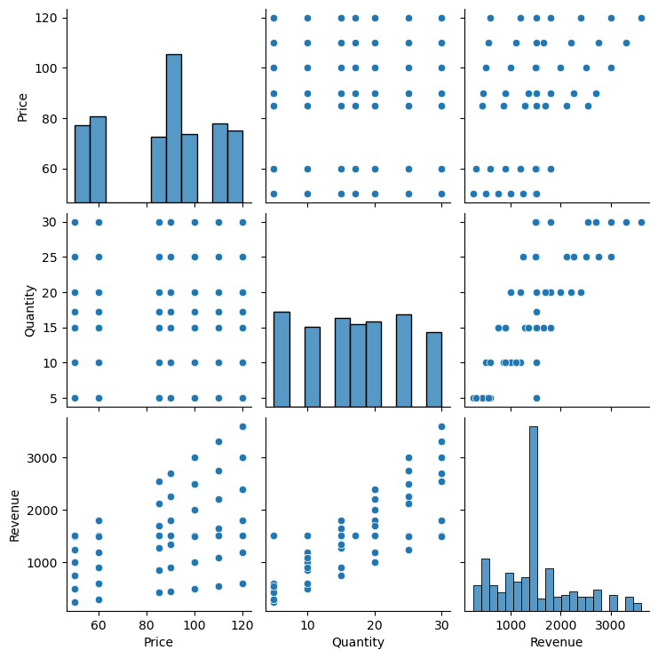

```python
sns.pairplot(df)
plt.show()
```

```python
x=df[["Price","Quantity"]]
y=df["Revenue"]
```

```python
print(x.shape)
```

```
(1000, 2)
```

```python
print(y.shape)
```

```
(1000,)
```

```python
from sklearn.model_selection import train_test_split
x_train,x_test,y_train,y_test=train_test_split(x,y,test_size=0.2,random_state=19)
```

```python
from sklearn.linear_model import LinearRegression
model=LinearRegression()
model.fit(x,y)
```

```
LinearRegression()
```

```python
print(model.intercept_)
```

```
-1080.211122217055
```

```python
print(model.coef_)
```

```
[14.71705792 75.85008154]
```

```python
ypred_train=model.predict(x_train)
```

```python
print("train r2:",model.score(x_train,y_train))
```

```
train r2: 0.8219543348380041
```

```python
ypred_test=model.predict(x_test)
```

```python
print("test r2:",model.score(x_test,y_test))
```

```
test r2: 0.8073239394077989
```

```python
from sklearn.metrics import r2_score
print("r2_score:",r2_score(ypred_test,y_test))
```

```
r2_score: 0.7812355944571876
```

```python
from sklearn.metrics import mean_squared_error
print("RMSE:",np.sqrt(mean_squared_error(ypred_test,y_test)))
```

```
RMSE: 314.6012979547582
```

```python
from sklearn.model_selection import cross_val_score
scores=cross_val_score(model,x,y,cv=5)
print(scores)
print("cross_val_score:",scores.mean())
```

```
[0.8422183  0.81555494 0.77859793 0.81155722 0.83779189]
cross_val_score: 0.8171440581242313
```

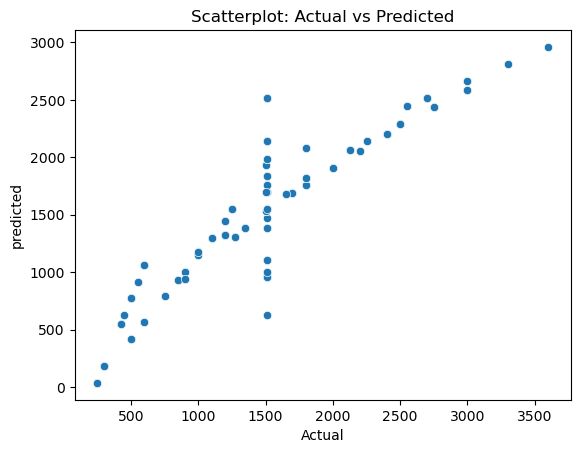

```python
sns.scatterplot(x=y_test, y=ypred_test)
plt.xlabel("Actual")
plt.ylabel("predicted")
plt.title("Scatterplot: Actual vs Predicted")
plt.show()
```

```python
result_df = pd.DataFrame({
    "Actual Sales": y_test,
    "Predicted Sales": ypred_test})
print(result_df.head(10))
```

```
     Actual Sales  Predicted Sales
800     900.00000       940.563576
773    1508.94526       958.380123
23     1508.94526      1761.325722
819    1650.00000      1676.416473
486     425.00000       549.989209
719    2250.00000      2140.576129
239    1508.94526      2519.826537
944     750.00000       793.392997
658    1500.00000      1699.064392
472    1800.00000      2078.314799
```

# conclusion:

The project focuses on estimating future sales using predicted sales data. To accomplish this, I utilized essential Python libraries such as NumPy, Pandas, Matplotlib, and Seaborn. The dataset contained missing values in key columns like Price, Quantity, and Revenue, which I handled by imputing the missing values using the mean and median of the respective columns. I then performed feature engineering on the Date column by decomposing it into individual time-based components such as day, month, and year. For visual analysis, I used a scatter plot to compare actual vs. predicted sales, helping to evaluate the performance of the model. Finally, I created a tabular comparison of actual and predicted sales using the Pandas library, which provided a clear and interpretable summary of the model's forecasting ability.